# Closeread example

## Let’s look at some Penguins!

**Palmer Penguins** is a popular open dataset used for teaching data science and statistics, a new alternative to the classic `iris` dataset.

It contains morphological measurements of three penguin species observed in the Palmer Archipelago in Antarctica:

Adelie

Chinstrap

and Gentoo

## How do I get the data?

The dataset is part of the `{palmerpenguins}` R package.

You can install it like this:

But if you have the new version of `R 4.5`, it’s now directly available!

```r
install.packages("palmerpenguins")
```

## Code Zoom Example

This is how you load libraries.

This calculates summary statistics.

But it looks a bit tiny, right?

That’s better!

```r
library(dplyr)
library(palmerpenguins)
head(penguins)
penguins %>%
  group_by(island) %>%
  summarize(avg_bill_length = mean(bill_length_mm))
```

## Plots and Penguins!

Let’s take a look at some data! We’ll explore how different penguin species vary in size using a simple scatter plot.

We will now see a plot in which the x-axis shows *flipper length* in millimeters, and the y-axis shows *body mass* in grams. Each point will represent a penguin.

Have a look at the **Gentoo**. They generally have larger flippers and higher body mass, and their measurements barely overlap with the other two species.

Now let’s look at **Adelie** and **Chinstrap** penguins. These two species overlap almost completely in both traits, making them harder to distinguish using just body size.

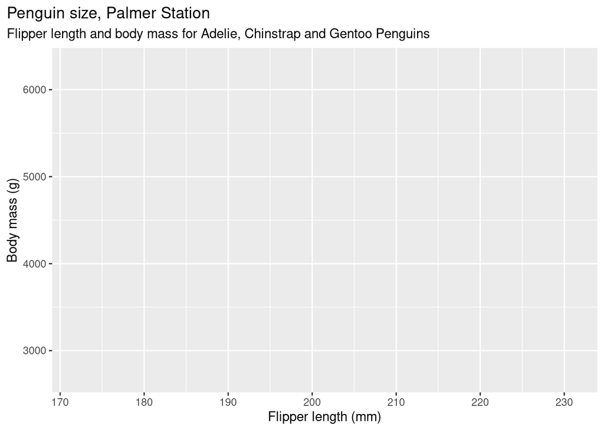

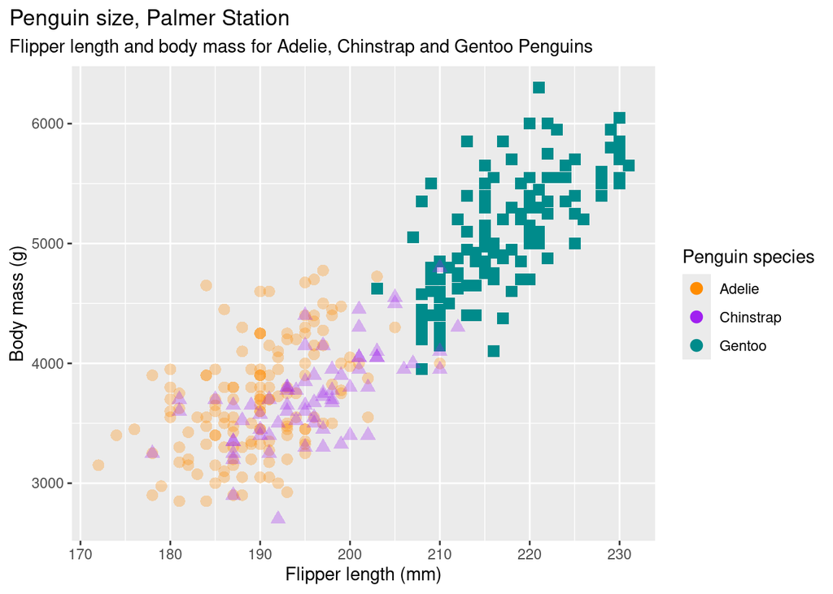

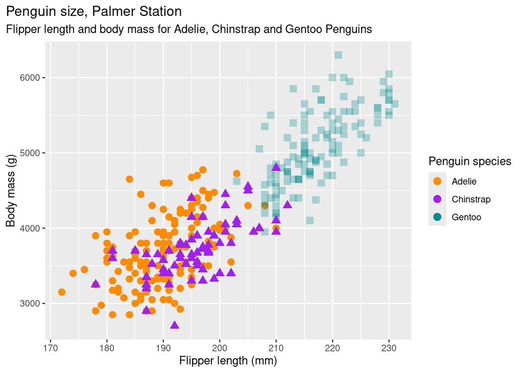